# Statistical comparison of V-region Library Preparation Protocols Across Each DNA Isolation Method on Toti Samples Analyzed With EMU on EMUdb

Balázs Kakuk

# 1 Notes

- Taxonomic Assignment: EMU, using EMU db
- Unclassified reads *were* excluded
- Taxa with total reads number of 10 or lower were excluded
- Read counts were not normalized
- The statistical tests were carried out on sample-wise *Bray-Curtis* distances
- PERMANOVA was carried out with combined (full) model (DNA_isolation_kit + Library)

# 2 Statistical Comparison of Library Preparation Methods and DNA Isolation Kits

- *PERMIDISP is a multivariate analysis of the homogeneity of groups dispersions (variances), which can be used as a means of assessing beta diversity.*
- *PERMANOVA: Permutational Multivariate Analysis of Variance Using Distance Matrices*

## 2.1 Comparison across all Libraries and All DNA Isolation Kits

### 2.1.1 Full model PERMANOVA

|  | Df | SumOfSqs | R2 | F | Pr(>F) |
| --- | --- | --- | --- | --- | --- |
| DNA_isolation_method | 3 | 3.269499 | 0.1607974 | 7.140452 | 0.001 |
| library | 4 | 7.905858 | 0.3888184 | 12.949553 | 0.001 |
| Residual | 60 | 9.157680 | 0.4503843 | NA | NA |
| Total | 67 | 20.333037 | 1.0000000 | NA | NA |

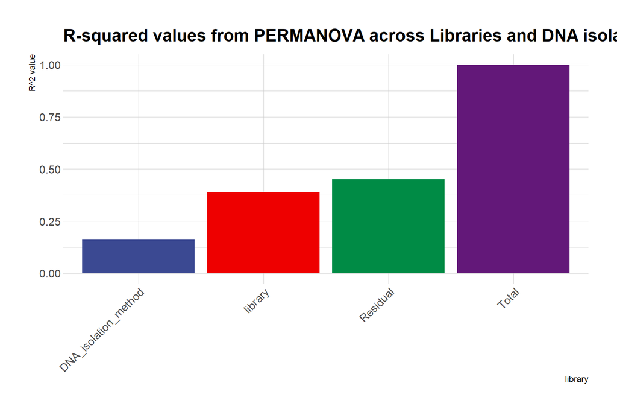

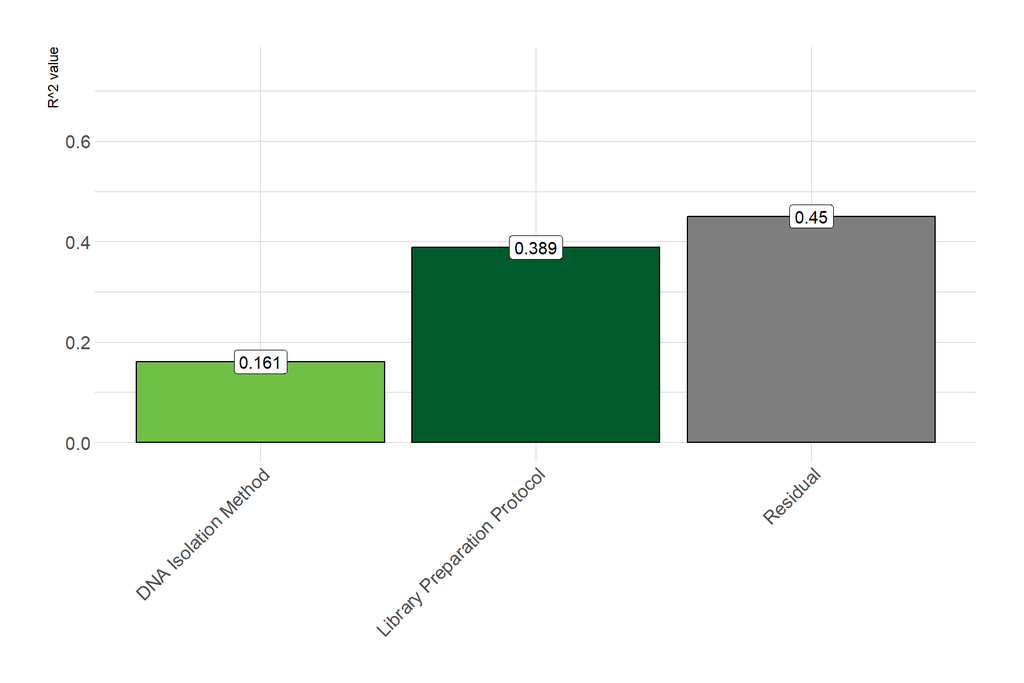

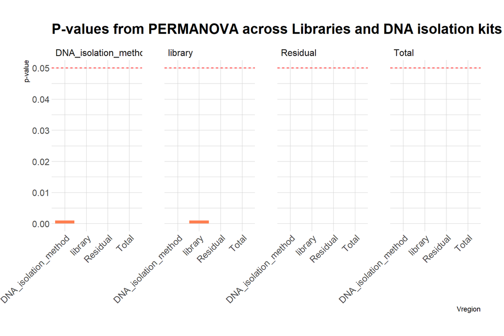

A p-value less than 0.05, indicate that the centroids of the groups in the multivariate space are significantly different.

### 2.1.2 PairWise PERMANOVA

| pairs | Df | SumsOfSqs | F.Model | R2 | p.value | p.adjusted | sig |
| --- | --- | --- | --- | --- | --- | --- | --- |
| V1_V2_Illumina vs V1_V3_Illumina | 1 | 1.7088283 | 7.778118 | 0.2302709 | 0.001 | 0.01 | * |
| V1_V2_Illumina vs V3_V4_Illumina | 1 | 0.9592533 | 22.335957 | 0.5037888 | 0.001 | 0.01 | * |
| V1_V2_Illumina vs V1_V9_ONT | 1 | 3.6980590 | 18.747625 | 0.4189636 | 0.001 | 0.01 | * |
| V1_V2_Illumina vs V1_V9_PacBio | 1 | 0.5891334 | 7.917017 | 0.2646326 | 0.001 | 0.01 | * |
| V1_V3_Illumina vs V3_V4_Illumina | 1 | 1.8742924 | 8.567102 | 0.2478398 | 0.001 | 0.01 | * |
| V1_V3_Illumina vs V1_V9_ONT | 1 | 1.3693118 | 4.161188 | 0.1218104 | 0.003 | 0.03 | . |
| V1_V3_Illumina vs V1_V9_PacBio | 1 | 1.7897049 | 7.292899 | 0.2190527 | 0.001 | 0.01 | * |
| V3_V4_Illumina vs V1_V9_ONT | 1 | 3.7589460 | 19.145495 | 0.4240843 | 0.001 | 0.01 | * |
| V3_V4_Illumina vs V1_V9_PacBio | 1 | 1.3505582 | 18.418178 | 0.4556905 | 0.001 | 0.01 | * |
| V1_V9_ONT vs V1_V9_PacBio | 1 | 3.4316644 | 15.391274 | 0.3718483 | 0.001 | 0.01 | * |

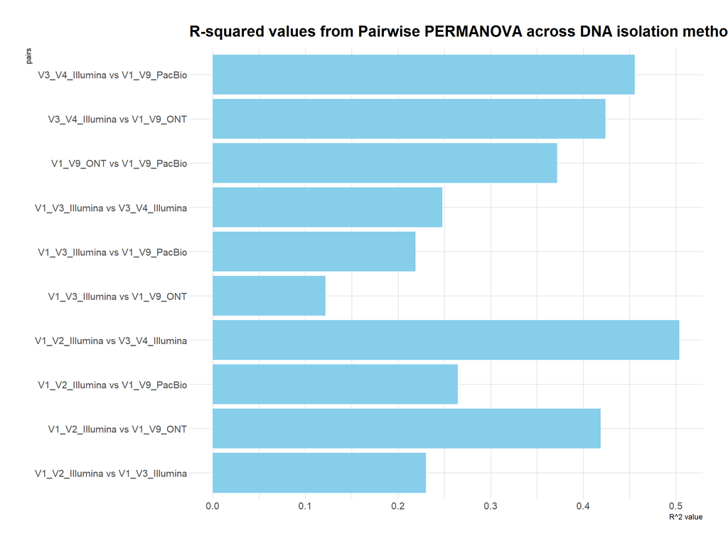

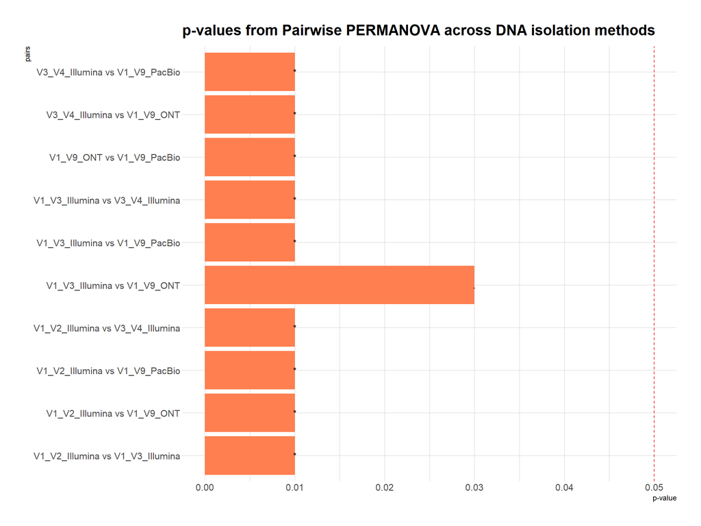

### 2.1.3 PERMDISP2

```
##
##  Homogeneity of multivariate dispersions
##
## Call: betadisper(d = dis, group = groups)
##
## No. of Positive Eigenvalues: 44
## No. of Negative Eigenvalues: 23
##
## Average distance to median:
## V1_V2_Illumina V1_V3_Illumina      V1_V9_ONT   V1_V9_PacBio V3_V4_Illumina
##         0.1879         0.5592         0.4888         0.2932         0.1850
##
## Eigenvalues for PCoA axes:
## (Showing 8 of 67 eigenvalues)
##  PCoA1  PCoA2  PCoA3  PCoA4  PCoA5  PCoA6  PCoA7  PCoA8
## 6.9274 2.8642 2.1356 1.4004 1.0685 0.9691 0.9203 0.5571
```

### 2.1.4 ANOVA on test results

|  | Df | Sum Sq | Mean Sq | F value | Pr(>F) |
| --- | --- | --- | --- | --- | --- |
| Groups | 4 | 1.675541 | 0.4188853 | 14.6057 | 0 |
| Residuals | 63 | 1.806813 | 0.0286796 | NA | NA |

### 2.1.5 Permutation test for F

```
##
## Permutation test for homogeneity of multivariate dispersions
## Permutation: free
## Number of permutations: 999
##
## Response: Distances
##           Df Sum Sq Mean Sq      F N.Perm Pr(>F)
## Groups     4 1.6755 0.41889 14.606    999  0.001 ***
## Residuals 63 1.8068 0.02868
## ---
## Signif. codes:  0 '***' 0.001 '**' 0.01 '*' 0.05 '.' 0.1 ' ' 1
##
## Pairwise comparisons:
## (Observed p-value below diagonal, permuted p-value above diagonal)
##                V1_V2_Illumina V1_V3_Illumina  V1_V9_ONT V1_V9_PacBio
## V1_V2_Illumina                    1.0000e-03 3.0000e-03   2.8000e-02
## V1_V3_Illumina     2.3810e-08                3.7800e-01   1.0000e-03
## V1_V9_ONT          1.4514e-03     3.7587e-01              3.5000e-02
## V1_V9_PacBio       2.7537e-02     1.8196e-05 3.2491e-02
## V3_V4_Illumina     9.3560e-01     1.0964e-08 1.2085e-03   1.8085e-02
##                V3_V4_Illumina
## V1_V2_Illumina          0.935
## V1_V3_Illumina          0.001
## V1_V9_ONT               0.003
## V1_V9_PacBio            0.020
## V3_V4_Illumina
```

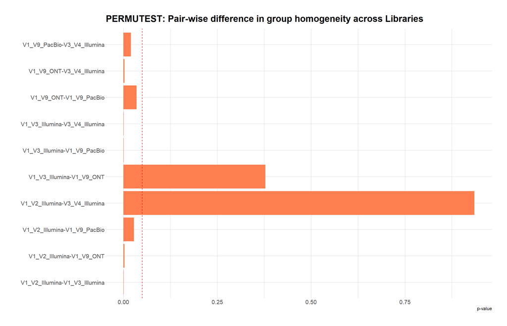

### 2.1.6 Tukey’s Honest Significant Differences

```
##   Tukey multiple comparisons of means
##     95% family-wise confidence level
##
## Fit: aov(formula = distances ~ group, data = df)
##
## $group
##                                      diff         lwr         upr     p adj
## V1_V3_Illumina-V1_V2_Illumina  0.37124842  0.18962750  0.55286934 0.0000029
## V1_V9_ONT-V1_V2_Illumina       0.30087888  0.11925796  0.48249980 0.0001645
## V1_V9_PacBio-V1_V2_Illumina    0.10525068 -0.08891025  0.29941161 0.5521071
## V3_V4_Illumina-V1_V2_Illumina -0.00295513 -0.19711606  0.19120580 0.9999992
## V1_V9_ONT-V1_V3_Illumina      -0.07036955 -0.23851784  0.09777875 0.7653131
## V1_V9_PacBio-V1_V3_Illumina   -0.26599774 -0.44761866 -0.08437682 0.0010591
## V3_V4_Illumina-V1_V3_Illumina -0.37420355 -0.55582447 -0.19258263 0.0000024
## V1_V9_PacBio-V1_V9_ONT        -0.19562820 -0.37724912 -0.01400728 0.0285720
## V3_V4_Illumina-V1_V9_ONT      -0.30383401 -0.48545493 -0.12221309 0.0001397
## V3_V4_Illumina-V1_V9_PacBio   -0.10820581 -0.30236674  0.08595512 0.5249808
```

### 2.1.7 PCoA and distances to centroid for each group

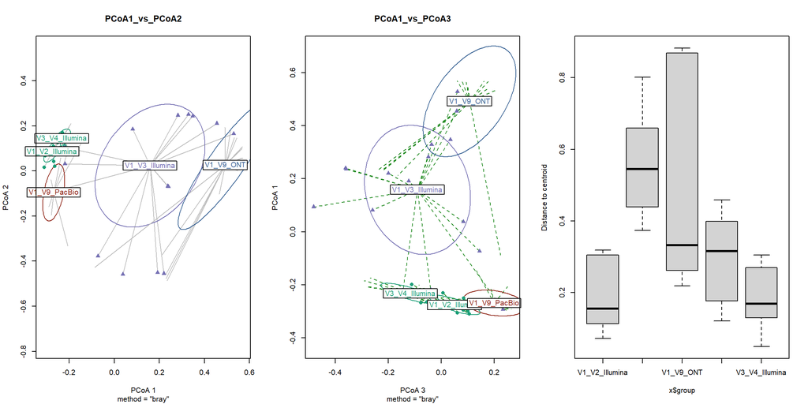

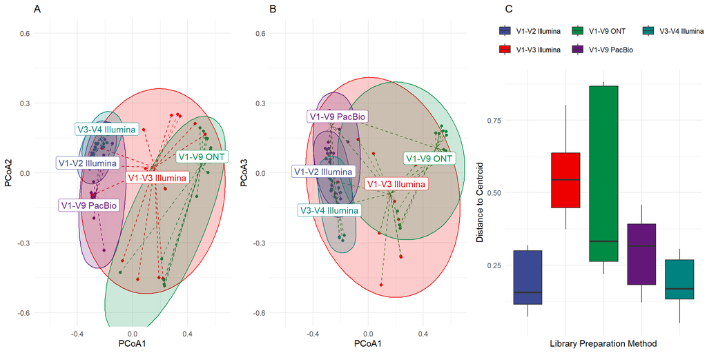

## 2.2 Comparison across all Libraries, with the exception of Qiagen V1-V9 Samples

### 2.2.1 Full model PERMANOVA

|  | Df | SumOfSqs | R2 | F | Pr(>F) |
| --- | --- | --- | --- | --- | --- |
| DNA_isolation_method | 3 | 2.393811 | 0.1362226 | 6.182299 | 0.001 |
| library | 4 | 7.951167 | 0.4524705 | 15.401120 | 0.001 |
| Residual | 56 | 7.227808 | 0.4113069 | NA | NA |
| Total | 63 | 17.572785 | 1.0000000 | NA | NA |

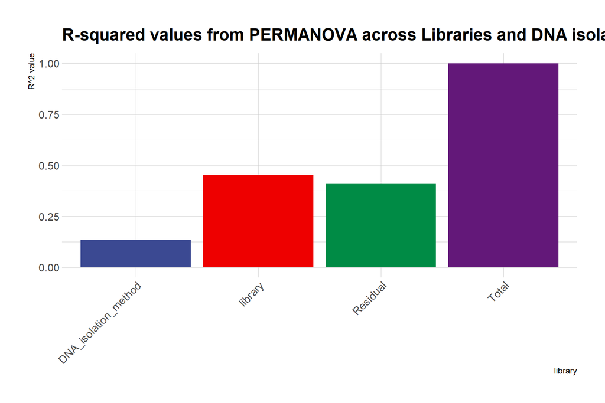

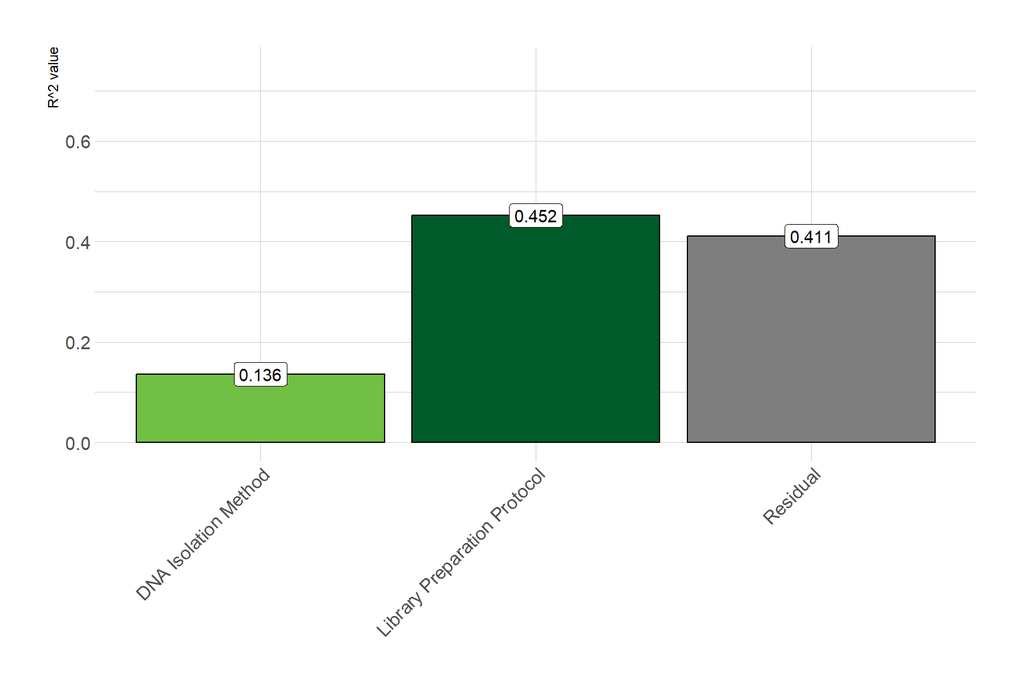

### 2.2.2 Supp Fig S1

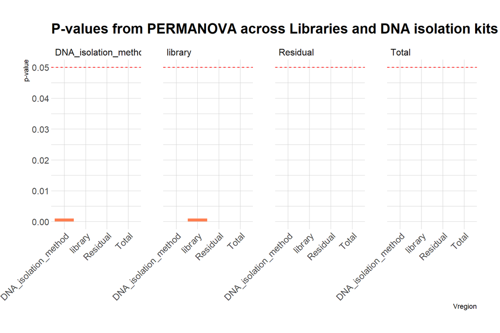

A p-value less than 0.05, indicate that the centroids of the groups in the multivariate space are significantly different.

### 2.2.3 PairWise PERMANOVA

| pairs | Df | SumsOfSqs | F.Model | R2 | p.value | p.adjusted | sig |
| --- | --- | --- | --- | --- | --- | --- | --- |
| V1_V2_Illumina vs V1_V3_Illumina | 1 | 1.7088283 | 7.778118 | 0.2302709 | 0.001 | 0.01 | * |
| V1_V2_Illumina vs V3_V4_Illumina | 1 | 0.9592533 | 22.335957 | 0.5037888 | 0.001 | 0.01 | * |
| V1_V2_Illumina vs V1_V9_ONT | 1 | 3.7846268 | 35.372535 | 0.6165413 | 0.001 | 0.01 | * |
| V1_V2_Illumina vs V1_V9_PacBio | 1 | 0.5891334 | 7.917017 | 0.2646326 | 0.001 | 0.01 | * |
| V1_V3_Illumina vs V3_V4_Illumina | 1 | 1.8742924 | 8.567102 | 0.2478398 | 0.001 | 0.01 | * |
| V1_V3_Illumina vs V1_V9_ONT | 1 | 1.6720364 | 6.125319 | 0.1906695 | 0.001 | 0.01 | * |
| V1_V3_Illumina vs V1_V9_PacBio | 1 | 1.7897049 | 7.292899 | 0.2190527 | 0.001 | 0.01 | * |
| V3_V4_Illumina vs V1_V9_ONT | 1 | 3.8514874 | 36.366602 | 0.6230721 | 0.001 | 0.01 | * |
| V3_V4_Illumina vs V1_V9_PacBio | 1 | 1.3505582 | 18.418178 | 0.4556905 | 0.001 | 0.01 | * |
| V1_V9_ONT vs V1_V9_PacBio | 1 | 3.5871823 | 26.112482 | 0.5427382 | 0.001 | 0.01 | * |

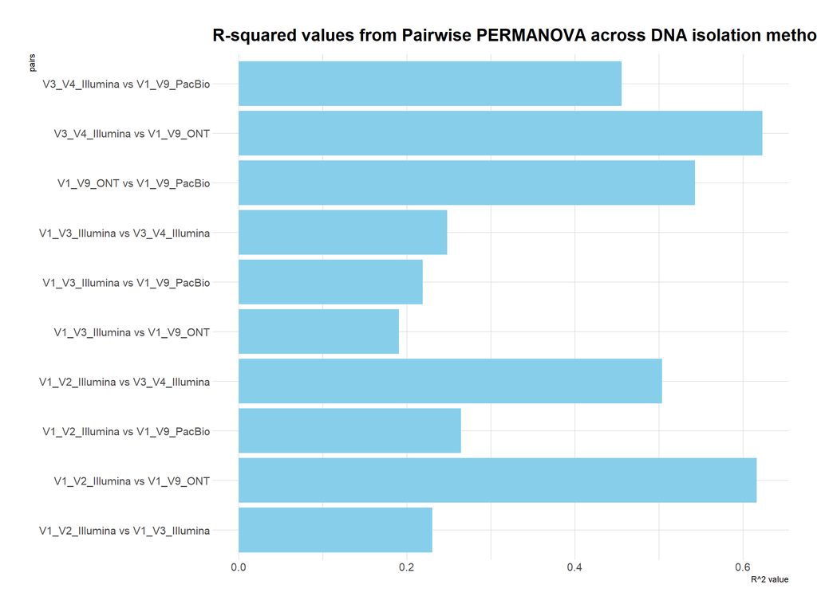

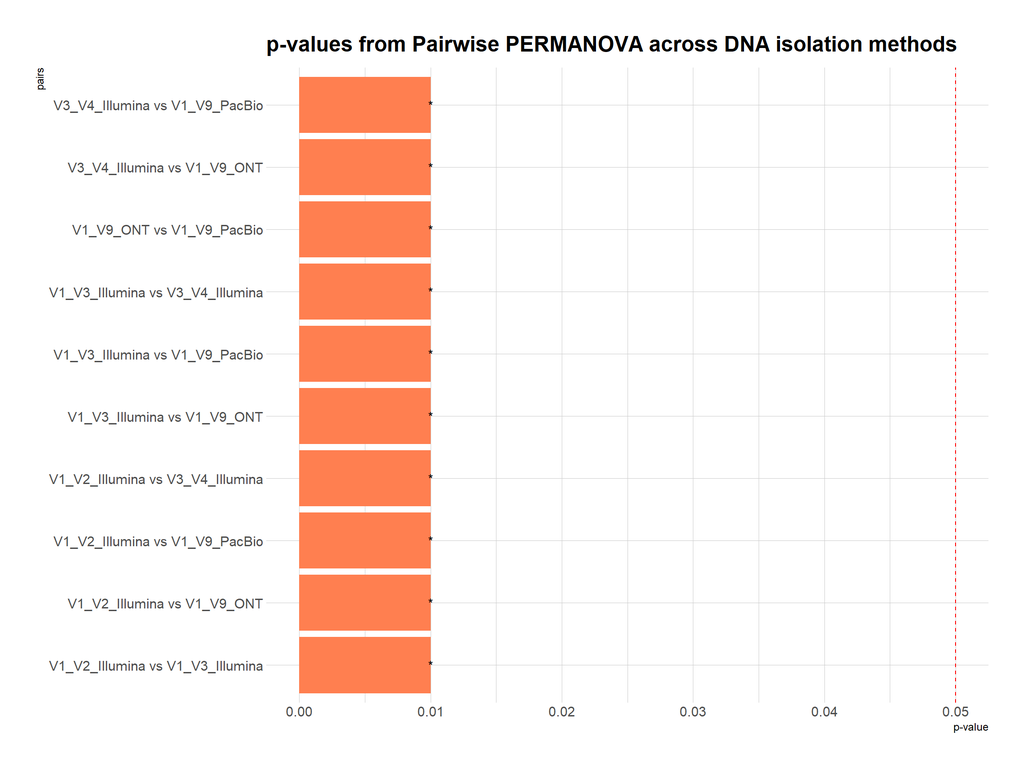

### 2.2.4 PERMDISP2

```
##
##  Homogeneity of multivariate dispersions
##
## Call: betadisper(d = dis, group = groups)
##
## No. of Positive Eigenvalues: 40
## No. of Negative Eigenvalues: 23
##
## Average distance to median:
## V1_V2_Illumina V1_V3_Illumina      V1_V9_ONT   V1_V9_PacBio V3_V4_Illumina
##         0.1879         0.5592         0.3468         0.2932         0.1850
##
## Eigenvalues for PCoA axes:
## (Showing 8 of 63 eigenvalues)
##  PCoA1  PCoA2  PCoA3  PCoA4  PCoA5  PCoA6  PCoA7  PCoA8
## 6.7672 2.4376 1.9064 1.1509 1.0138 0.9467 0.7497 0.4002
```

### 2.2.5 ANOVA on test results

|  | Df | Sum Sq | Mean Sq | F value | Pr(>F) |
| --- | --- | --- | --- | --- | --- |
| Groups | 4 | 1.354614 | 0.3386534 | 17.30438 | 0 |
| Residuals | 59 | 1.154652 | 0.0195704 | NA | NA |

### 2.2.6 Permutation test for F

```
##
## Permutation test for homogeneity of multivariate dispersions
## Permutation: free
## Number of permutations: 999
##
## Response: Distances
##           Df Sum Sq Mean Sq      F N.Perm Pr(>F)
## Groups     4 1.3546 0.33865 17.304    999  0.001 ***
## Residuals 59 1.1546 0.01957
## ---
## Signif. codes:  0 '***' 0.001 '**' 0.01 '*' 0.05 '.' 0.1 ' ' 1
##
## Pairwise comparisons:
## (Observed p-value below diagonal, permuted p-value above diagonal)
##                V1_V2_Illumina V1_V3_Illumina  V1_V9_ONT V1_V9_PacBio
## V1_V2_Illumina                    1.0000e-03 2.4000e-02   3.2000e-02
## V1_V3_Illumina     2.3850e-08                4.0000e-03   1.0000e-03
## V1_V9_ONT          3.0186e-02     4.2381e-03              4.9800e-01
## V1_V9_PacBio       2.7545e-02     1.8214e-05 4.6452e-01
## V3_V4_Illumina     9.3564e-01     1.0982e-08 2.4730e-02   1.8090e-02
##                V3_V4_Illumina
## V1_V2_Illumina          0.915
## V1_V3_Illumina          0.001
## V1_V9_ONT               0.031
## V1_V9_PacBio            0.024
## V3_V4_Illumina
```

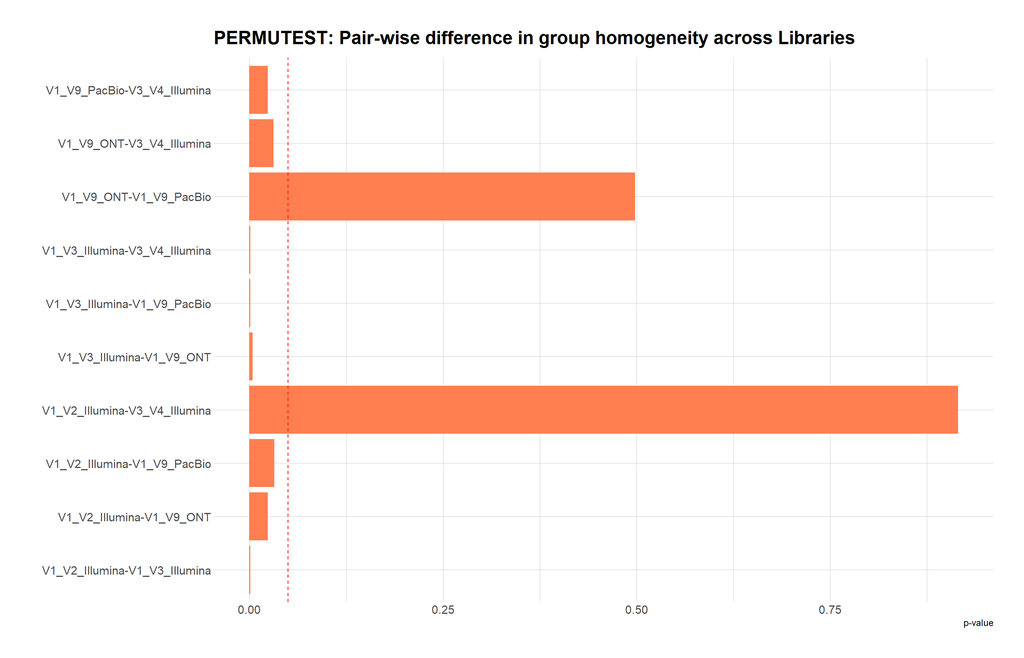

### 2.2.7 Tukey’s Honest Significant Differences

```
##   Tukey multiple comparisons of means
##     95% family-wise confidence level
##
## Fit: aov(formula = distances ~ group, data = df)
##
## $group
##                                       diff          lwr          upr     p adj
## V1_V3_Illumina-V1_V2_Illumina  0.371250242  0.220922053  0.521578431 0.0000000
## V1_V9_ONT-V1_V2_Illumina       0.158860597 -0.001846996  0.319568191 0.0541521
## V1_V9_PacBio-V1_V2_Illumina    0.105247894 -0.055459700  0.265955487 0.3594056
## V3_V4_Illumina-V1_V2_Illumina -0.002953429 -0.163661023  0.157754164 0.9999983
## V1_V9_ONT-V1_V3_Illumina      -0.212389645 -0.362717833 -0.062061456 0.0017563
## V1_V9_PacBio-V1_V3_Illumina   -0.266002348 -0.416330537 -0.115674159 0.0000563
## V3_V4_Illumina-V1_V3_Illumina -0.374203671 -0.524531860 -0.223875483 0.0000000
## V1_V9_PacBio-V1_V9_ONT        -0.053612703 -0.214320297  0.107094890 0.8805858
## V3_V4_Illumina-V1_V9_ONT      -0.161814026 -0.322521620 -0.001106433 0.0476473
## V3_V4_Illumina-V1_V9_PacBio   -0.108201323 -0.268908917  0.052506270 0.3315888
```

### 2.2.8 PCoA and distances to centroid for each group

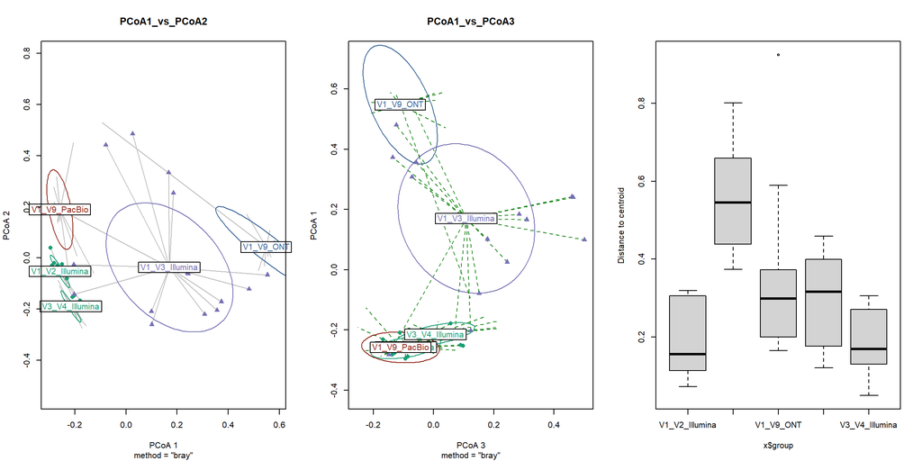

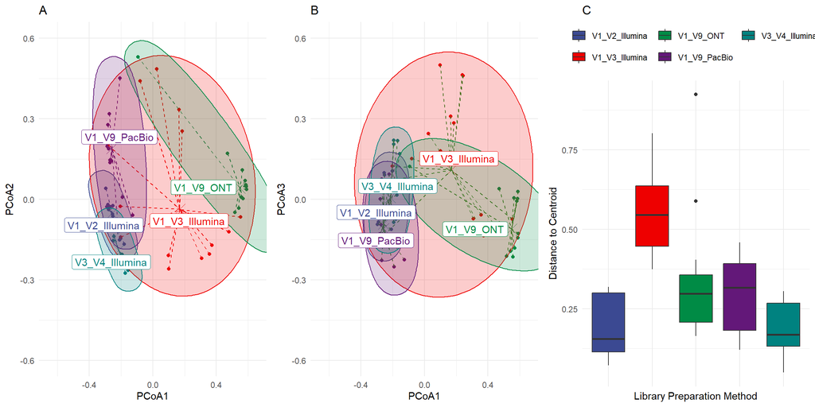